# ML Factor analysis

#### Default import

(not all deployed)

```python
import pandas as pd
import numpy as np
from datetime import datetime
from pandas import Series, ExcelWriter
from sklearn import preprocessing
from sklearn.model_selection import train_test_split
from sklearn.linear_model import LinearRegression
from sklearn.ensemble import RandomForestRegressor
from sklearn.svm import SVC
from sklearn.datasets import make_regression
from sklearn.linear_model import LogisticRegression, RidgeClassifier
from sklearn.tree import DecisionTreeClassifier
from sklearn.ensemble import BaggingClassifier
import seaborn as sns
from sklearn.model_selection import TimeSeriesSplit
import random
from sklearn import linear_model
from sklearn.linear_model import LogisticRegression
from sklearn.metrics import roc_auc_score, make_scorer, roc_curve, f1_score
from sklearn.metrics import confusion_matrix, precision_score, accuracy_score, recall_score,r2_score
from sklearn.model_selection import GridSearchCV, KFold, cross_val_predict
from sklearn.model_selection import cross_validate, ShuffleSplit, learning_curve
from scipy import stats
import matplotlib.pyplot as plt
import matplotlib
import warnings
from sklearn.ensemble import AdaBoostClassifier
warnings.filterwarnings("ignore")
from sklearn.preprocessing import PolynomialFeatures
from sklearn.svm import NuSVC
import xlwt
from openpyxl import load_workbook
from pandas.plotting import scatter_matrix
from sklearn.ensemble import RandomForestClassifier
%matplotlib inline
pd.set_option('display.max_rows', 1000)
from sklearn.utils.multiclass import unique_labels
```

## 1) Gathering and preparing data

#### Read the dataset

```python
df = pd.read_excel('dataSandwichDef.xlsx')
df
```

|  | REF_DATE | SEDOLCHK | SIMPLE_TOT_RET | COMPOUND_TOT_RET | FIVE_YR_VOLATILITY_M | FIVE_YR_VOLATILITY_W | ADY | AERR | AGRE | APE | ... | REV_STD_MARK | ROE | TRL_ECM | TRL_GRE | TURNOVER_1M | UL_SALES | PB/PCF1 | PB/PCF2 | ICB_INDUSTRY_NUM | ICB_SECTOR_NUM |
| --- | --- | --- | --- | --- | --- | --- | --- | --- | --- | --- | --- | --- | --- | --- | --- | --- | --- | --- | --- | --- | --- |
| 0 | 20050429 | 0028262 | 0.014546 | 0.015183 | 0.374144 | 0.410857 | 0.034056 | 0.583228 | 0.038748 | 12.237950 | ... | 4.747419e-05 | 0.228026 | -0.008689 | 0.039583 | 13.452780 | 0.025476 | 6.840467 | 6.840467 | 1 | 570 |
| 1 | 20050429 | 0038614 | 0.043240 | 0.043240 | 0.243429 | 0.240235 | 0.058831 | 0.424596 | 0.069312 | 9.780680 | ... | -9.534020e-05 | 0.203544 | 0.006073 | 0.033105 | 34.522570 | 0.409729 | 1.914199 | 1.914199 | 8000 | 8350 |
| 2 | 20050429 | 0044473 | 0.043979 | 0.043979 | 0.457628 | 0.457729 | 0.033439 | 0.485167 | 0.058342 | 15.396250 | ... | 2.637850e-04 | NaN | -0.166107 | 0.168180 | 35.399190 | 0.072399 | 21.041570 | 21.041570 | 5000 | 5550 |
| 3 | 20050429 | 0045614 | 0.062633 | 0.064127 | 0.330014 | 0.296963 | 0.038021 | 0.720774 | 1.868184 | 7.344045 | ... | -9.539962e-05 | 0.270775 | -0.021343 | -0.174962 | 20.178210 | 0.602459 | 5.907725 | 5.907725 | 1000 | 1770 |
| 4 | 20050429 | 0047245 | 0.063380 | 0.063380 | 0.380265 | 0.394760 | 0.049925 | 0.411554 | 0.040607 | 11.786590 | ... | -4.898203e-04 | 0.165902 | 0.003204 | 0.036071 | 41.796300 | 0.049196 | 7.831871 | 7.831871 | 5000 | 5370 |
| 5 | 20050429 | 0056434 | 0.059750 | 0.059750 | 0.182101 | 0.223632 | 0.034764 | 0.471754 | -0.022939 | 15.195340 | ... | 1.812988e-04 | 0.095197 | 0.027764 | 0.028953 | 6.201680 | 0.315357 | 11.308350 | 11.308350 | 2000 | 2770 |
| 6 | 20050429 | 0059585 | 0.127937 | 0.127937 | 0.629962 | 0.688803 | 0.007311 | 0.781065 | 0.706227 | 29.947240 | ... | 2.408951e-04 | 0.092863 | 0.058180 | 0.237464 | 28.511660 | 0.265918 | 22.803050 | 22.803050 | 9000 | 9570 |
| 7 | 20050429 | 0067340 | 0.074202 | 0.074202 | 0.221773 | 0.219844 | 0.034016 | 0.425858 | 0.029890 | 16.878610 | ... | 2.051078e-04 | 0.079649 | 0.049833 | 0.078251 | 42.463440 | 0.280788 | 8.960947 | 8.960947 | 2000 | 2770 |
| 8 | 20050429 | 0068707 | 0.127472 | 0.127472 | 0.297374 | 0.334800 | 0.030875 | 0.520160 | 0.191679 | 15.541450 | ... | 1.180329e-03 | 0.208406 | 0.062097 | 0.102255 | 27.465940 | 0.117220 | 7.710687 | 7.710687 | 2000 | 2350 |
| 9 | 20050429 | 0081180 | 0.107563 | 0.107563 | 0.309365 | 0.326087 | 0.040927 | 0.782778 | 0.125733 | 5.307481 | ... | -2.258343e-03 | 0.191509 | 0.003240 | 0.011452 | 18.674230 | 0.152869 | 5.087405 | 5.087405 | 3000 | 3720 |
| 10 | 20050429 | 0090498 | 0.115183 | 0.115183 | 0.311594 | 0.287852 | 0.036189 | 0.789373 | 0.153873 | 5.820184 | ... | 1.759485e-03 | 0.188853 | 0.027925 | 0.069023 | 5.498901 | 0.187574 | 5.074012 | 5.074012 | 3000 | 3720 |
| 11 | 20050429 | 0096162 | 0.061576 | 0.061576 | 0.393006 | 0.394376 | 0.021675 | 0.714570 | 0.126908 | 13.168740 | ... | -1.672448e-04 | 0.252909 | 0.023294 | 0.079338 | 10.631300 | 0.038443 | 8.815166 | 8.815166 | 2000 | 2350 |
| 12 | 20050429 | 0108120 | 0.037113 | 0.037113 | 0.187568 | 0.259899 | 0.041655 | 0.376517 | 0.168142 | 14.967690 | ... | 1.015925e-04 | 0.192128 | 0.027682 | 0.075265 | 32.458570 | 0.133248 | 7.217163 | 7.217163 | 1000 | 1350 |
| 13 | 20050429 | 0136701 | 0.064181 | 0.064181 | 0.218047 | 0.219055 | 0.017358 | 0.514363 | 0.092632 | 27.977750 | ... | 2.919058e-06 | 0.026591 | -0.035097 | 0.090314 | 30.219090 | 0.321656 | 0.778794 | 39.834690 | 8000 | 8670 |
| 14 | 20050429 | 0141192 | 0.010185 | 0.010185 | 0.355280 | 0.383283 | 0.013927 | 0.671229 | 0.580844 | 23.606700 | ... | 3.265326e-04 | 1.327049 | 0.098355 | 0.173178 | 82.527180 | 0.190738 | 15.186550 | 15.186550 | 5000 | 5550 |
| 15 | 20050429 | 0142162 | 0.005634 | 0.005634 | 0.272886 | 0.307773 | 0.034507 | 0.361722 | -0.069647 | 18.497050 | ... | 7.639617e-05 | 0.174348 | -0.012353 | 0.026980 | 13.466810 | 0.054693 | 8.468521 | 8.468521 | 1000 | 1350 |
| 16 | 20050429 | 0143002 | 0.146418 | 0.146418 | 0.198010 | 0.245205 | 0.035826 | 0.206897 | -0.032366 | 22.137930 | ... | -1.034338e-03 | 0.037366 | 0.017339 | 0.008340 | 5.900607 | 0.399887 | 0.825208 | 32.424240 | 8000 | 8670 |
| 17 | 20050429 | 0145279 | -0.008737 | -0.008737 | 0.195831 | 0.239101 | 0.035618 | 0.643817 | 0.117117 | 10.000000 | ... | 4.131867e-04 | 0.194816 | 0.025039 | 0.100470 | 46.564280 | 0.596695 | 1.764287 | 1.764287 | 8000 | 8350 |
| 18 | 20050429 | 0150080 | 0.042122 | 0.042122 | 0.390497 | 0.383167 | 0.008779 | 0.804705 | 1.476182 | 22.246070 | ... | -4.370172e-03 | 0.144668 | -0.106661 | 0.329116 | 11.601820 | 0.348257 | 4.160715 | 4.160715 | 1 | 530 |
| 19 | 20050429 | 0180366 | 0.049464 | 0.049464 | 0.304141 | 0.290389 | 0.046166 | 0.533644 | 0.141072 | 10.101630 | ... | -1.457009e-02 | 0.199096 | -0.066363 | -0.049020 | 20.975460 | 0.190406 | 2.341711 | NaN | 8000 | 8770 |
| 20 | 20050429 | 0185929 | 0.101449 | 0.101449 | 0.269484 | 0.268006 | 0.032206 | 0.768450 | 0.167222 | 7.189631 | ... | 7.413559e-04 | 0.171101 | 0.032460 | 0.057199 | 7.364349 | 0.240092 | 6.681127 | 6.681127 | 3000 | 3720 |
| 21 | 20050429 | 0191539 | -0.007306 | -0.007419 | 0.381169 | 0.413260 | 0.015982 | 0.718391 | 0.189926 | 17.620650 | ... | -6.639972e-05 | 0.626193 | 0.019082 | 0.136964 | 6.650748 | 0.096985 | 10.589430 | 10.589430 | 5000 | 5550 |
| 22 | 20050429 | 0216238 | 0.045840 | 0.045840 | 0.369100 | 0.347868 | 0.043056 | 0.604027 | 0.211903 | 9.196702 | ... | 3.075865e-04 | 0.169977 | 0.035972 | 0.040266 | 98.512910 | 0.058578 | 1.505508 | NaN | 8000 | 8570 |
| 23 | 20050429 | 0222815 | 0.014791 | 0.014791 | 0.229297 | 0.233406 | 0.056204 | 0.465625 | -0.009880 | 9.507813 | ... | 6.145139e-04 | 0.156438 | 0.046121 | 0.028137 | 15.699060 | 0.507566 | 1.473566 | 8.451390 | 8000 | 8770 |
| 24 | 20050429 | 0230346 | 0.053465 | 0.053465 | 0.277499 | 0.294308 | 0.037426 | 0.578849 | 0.246898 | 11.252980 | ... | 2.652912e-04 | 0.149187 | 0.029991 | -0.043164 | 8.026033 | 0.064041 | 5.186815 | 5.186815 | 2000 | 2770 |
| 25 | 20050429 | 0237400 | 0.021318 | 0.021318 | 0.185060 | 0.226054 | 0.036946 | 0.404516 | -0.010681 | 16.117900 | ... | -2.572283e-04 | 0.363076 | 0.008550 | 0.057975 | 279.507100 | 0.220986 | 13.789720 | 13.789720 | 3000 | 3530 |
| 26 | 20050429 | 0240549 | 0.121302 | 0.121302 | 0.365693 | 0.367335 | 0.029586 | 0.474662 | 0.990318 | 17.756440 | ... | -6.484695e-04 | 0.093512 | 0.146252 | 0.079215 | 12.275730 | 0.316095 | 1.668394 | NaN | 8000 | 8770 |
| 27 | 20050429 | 0250281 | 0.095183 | 0.095183 | 0.390954 | 0.301469 | 0.041846 | 0.625806 | 0.075522 | 8.942266 | ... | 1.439877e-04 | 0.238232 | -0.006748 | -0.090117 | 6.021392 | 0.064105 | 5.319484 | 5.319484 | 3000 | 3570 |
| 28 | 20050429 | 0263494 | 0.054848 | 0.054848 | 0.344434 | 0.415757 | 0.037218 | 0.472222 | 0.081503 | 14.180560 | ... | 7.404845e-04 | 0.125697 | -0.014099 | 0.151619 | 98.346920 | 0.062950 | 10.684070 | 10.684070 | 2000 | 2710 |
| 29 | 20050429 | 0287580 | 0.067485 | 0.067485 | 0.221980 | 0.237267 | 0.042843 | 0.447356 | 0.095420 | 12.899410 | ... | 3.009584e-04 | 0.360070 | 0.055737 | 0.070758 | 137.912600 | 0.229035 | 11.133880 | 11.133880 | 3000 | 3780 |

[output cut: 971 more lines]

102186 rows × 71 columns

#### Initially, the DataFrame' shape is:

```python
df.shape
```

```
(102186, 71)
```

#### A brief descriptive statistics

```python
df.describe()
```

|  | REF_DATE | SIMPLE_TOT_RET | COMPOUND_TOT_RET | FIVE_YR_VOLATILITY_M | FIVE_YR_VOLATILITY_W | ADY | AERR | AGRE | APE | CGR | ... | REV_STD_MARK | ROE | TRL_ECM | TRL_GRE | TURNOVER_1M | UL_SALES | PB/PCF1 | PB/PCF2 | ICB_INDUSTRY_NUM | ICB_SECTOR_NUM |
| --- | --- | --- | --- | --- | --- | --- | --- | --- | --- | --- | --- | --- | --- | --- | --- | --- | --- | --- | --- | --- | --- |
| count | 1.021860e+05 | 102123.000000 | 102123.000000 | 102117.000000 | 102166.000000 | 101725.000000 | 97696.000000 | 98359.000000 | 98655.000000 | 91737.000000 | ... | 101522.000000 | 100096.000000 | 100917.000000 | 99730.000000 | 102181.000000 | 100817.000000 | 100402.000000 | 95690.000000 | 102186.000000 | 102186.000000 |
| mean | 2.011952e+07 | 0.007547 | 0.007559 | 0.294503 | 0.318929 | 0.032016 | 0.534007 | 0.100637 | 21.444112 | 0.087949 | ... | 0.000170 | 0.348933 | -0.014937 | 0.274704 | 48.888685 | 0.312801 | 11.413676 | 19.358099 | 4546.132171 | 5123.688989 |
| std | 4.130217e+04 | 0.089001 | 0.089089 | 0.122787 | 0.123919 | 0.024878 | 0.251277 | 6.737749 | 201.648041 | 0.161897 | ... | 0.048378 | 28.760040 | 6.082885 | 8.235621 | 87.572134 | 21.016170 | 182.832468 | 1502.180461 | 2766.850720 | 2739.592965 |
| min | 2.005043e+07 | -0.966300 | -0.966300 | 0.004800 | 0.022600 | 0.000000 | 0.000000 | -644.973400 | 0.330000 | -0.740100 | ... | -2.176300 | -63.500000 | -1585.904000 | -56.254700 | 0.189400 | -215.900000 | 0.030000 | 0.030000 | 1.000000 | 530.000000 |
| 25% | 2.008103e+07 | -0.037400 | -0.037400 | 0.210600 | 0.236100 | 0.017300 | 0.395100 | -0.045200 | 11.730000 | 0.011200 | ... | -0.000300 | 0.092300 | -0.020100 | 0.031900 | 9.128900 | 0.100000 | 3.510000 | 5.910000 | 2000.000000 | 2750.000000 |
| 50% | 2.012053e+07 | 0.009100 | 0.009100 | 0.266600 | 0.291300 | 0.028500 | 0.560800 | 0.077100 | 15.630000 | 0.076500 | ... | 0.000300 | 0.143900 | 0.019100 | 0.095500 | 20.311400 | 0.100000 | 7.980000 | 9.610000 | 4000.000000 | 4570.000000 |
| 75% | 2.015123e+07 | 0.054900 | 0.055000 | 0.345800 | 0.371300 | 0.042700 | 0.691600 | 0.209900 | 20.943230 | 0.143300 | ... | 0.000800 | 0.206900 | 0.056900 | 0.169300 | 49.226300 | 0.200000 | 12.710000 | 14.370000 | 8000.000000 | 8350.000000 |
| max | 2.019063e+07 | 1.694300 | 1.694300 | 1.412344 | 2.517600 | 1.205400 | 1.000000 | 220.160300 | 38766.150000 | 2.504540 | ... | 13.427800 | 8831.764000 | 504.193800 | 1844.659000 | 2571.911000 | 6310.000000 | 26172.750000 | 460769.000000 | 9000.000000 | 9570.000000 |

8 rows × 70 columns

#### Info on the type of each column and the number of non-NaN values

```python
df.info()
```

```
<class 'pandas.core.frame.DataFrame'>
RangeIndex: 102186 entries, 0 to 102185
Data columns (total 71 columns):
REF_DATE                 102186 non-null int64
SEDOLCHK                 102186 non-null object
SIMPLE_TOT_RET           102123 non-null float64
COMPOUND_TOT_RET         102123 non-null float64
FIVE_YR_VOLATILITY_M     102117 non-null float64
FIVE_YR_VOLATILITY_W     102166 non-null float64
ADY                      101725 non-null float64
AERR                     97696 non-null float64
AGRE                     98359 non-null float64
APE                      98655 non-null float64
CGR                      91737 non-null float64
CV3Y_EPS                 101932 non-null float64
CV3Y_EREV_FY1            101808 non-null float64
CV3Y_REP_EPS             102063 non-null float64
CV3Y_REV_MARK            101915 non-null float64
CV5Y_EPS                 101962 non-null float64
CV6M_P                   102180 non-null float64
CV6M_PM6M                101896 non-null float64
DEBT_MKT_CAP             90004 non-null float64
DY_FWD                   101856 non-null float64
DY_TRL                   101779 non-null float64
EBIT_SALES               97012 non-null float64
ECM                      101034 non-null float64
EEREV                    101683 non-null float64
EPS_SIGMA                100929 non-null float64
EPSDISP                  100891 non-null float64
EREV                     101556 non-null float64
F2GRE                    101635 non-null float64
FDY                      101777 non-null float64
FERR                     99738 non-null float64
FGRE                     99392 non-null float64
FPE                      100469 non-null float64
FWD_ECM                  101344 non-null float64
FWD_GRE                  101092 non-null float64
LRE                      95747 non-null float64
MKT_CAP_SALES            100610 non-null float64
NM                       100982 non-null float64
```

[output cut: 21 more lines]

```
REC_MARK_3M              101331 non-null float64
REV_MARK_1M              101639 non-null float64
REV_MARK_3M              101549 non-null float64
REV_STD_MARK             101522 non-null float64
ROE                      100096 non-null float64
TRL_ECM                  100917 non-null float64
TRL_GRE                  99730 non-null float64
TURNOVER_1M              102181 non-null float64
UL_SALES                 100817 non-null float64
PB/PCF1                  100402 non-null float64
PB/PCF2                  95690 non-null float64
ICB_INDUSTRY_NUM         102186 non-null int64
ICB_SECTOR_NUM           102186 non-null int64
dtypes: float64(67), int64(3), object(1)
memory usage: 55.4+ MB
```

#### Percentage of NaN values in each column

```python
df.isna().sum() / len(df)
```

```
REF_DATE                 0.000000
SEDOLCHK                 0.000000
SIMPLE_TOT_RET           0.000617
COMPOUND_TOT_RET         0.000617
FIVE_YR_VOLATILITY_M     0.000675
FIVE_YR_VOLATILITY_W     0.000196
ADY                      0.004511
AERR                     0.043939
AGRE                     0.037451
APE                      0.034555
CGR                      0.102255
CV3Y_EPS                 0.002486
CV3Y_EREV_FY1            0.003699
CV3Y_REP_EPS             0.001204
CV3Y_REV_MARK            0.002652
CV5Y_EPS                 0.002192
CV6M_P                   0.000059
CV6M_PM6M                0.002838
DEBT_MKT_CAP             0.119214
DY_FWD                   0.003229
DY_TRL                   0.003983
EBIT_SALES               0.050633
ECM                      0.011274
EEREV                    0.004922
EPS_SIGMA                0.012301
EPSDISP                  0.012673
EREV                     0.006165
F2GRE                    0.005392
FDY                      0.004003
FERR                     0.023956
FGRE                     0.027342
FPE                      0.016803
FWD_ECM                  0.008240
FWD_GRE                  0.010706
LRE                      0.063013
MKT_CAP_SALES            0.015423
NM                       0.011782
PB                       0.019739
PM6MBIS                  0.002799
PM6MTRIS                 0.002799
```

[output cut: 17 more lines]

```
REC_MARK_1M              0.007203
REC_MARK_3M              0.008367
REV_MARK_1M              0.005353
REV_MARK_3M              0.006234
REV_STD_MARK             0.006498
ROE                      0.020453
TRL_ECM                  0.012419
TRL_GRE                  0.024035
TURNOVER_1M              0.000049
UL_SALES                 0.013397
PB/PCF1                  0.017458
PB/PCF2                  0.063570
ICB_INDUSTRY_NUM         0.000000
ICB_SECTOR_NUM           0.000000
dtype: float64
```

## Fixing Nan based on rules

### Rule 1:

RF (i, j, t) = NA con j = SIMPLE_TOT_RET oppure j = COMPOUND_TOT_RET --> si sopprime la coppia (i, t) su ogni j: si tratta di una company delistata al termpo t

```python
df = df.dropna(subset = ['SIMPLE_TOT_RET', 'COMPOUND_TOT_RET']).reset_index().drop(['index'], axis = 1)
df.head()
```

|  | REF_DATE | SEDOLCHK | SIMPLE_TOT_RET | COMPOUND_TOT_RET | FIVE_YR_VOLATILITY_M | FIVE_YR_VOLATILITY_W | ADY | AERR | AGRE | APE | ... | REV_STD_MARK | ROE | TRL_ECM | TRL_GRE | TURNOVER_1M | UL_SALES | PB/PCF1 | PB/PCF2 | ICB_INDUSTRY_NUM | ICB_SECTOR_NUM |
| --- | --- | --- | --- | --- | --- | --- | --- | --- | --- | --- | --- | --- | --- | --- | --- | --- | --- | --- | --- | --- | --- |
| 0 | 20050429 | 0028262 | 0.014546 | 0.015183 | 0.374144 | 0.410857 | 0.034056 | 0.583228 | 0.038748 | 12.237950 | ... | 0.000047 | 0.228026 | -0.008689 | 0.039583 | 13.45278 | 0.025476 | 6.840467 | 6.840467 | 1 | 570 |
| 1 | 20050429 | 0038614 | 0.043240 | 0.043240 | 0.243429 | 0.240235 | 0.058831 | 0.424596 | 0.069312 | 9.780680 | ... | -0.000095 | 0.203544 | 0.006073 | 0.033105 | 34.52257 | 0.409729 | 1.914199 | 1.914199 | 8000 | 8350 |
| 2 | 20050429 | 0044473 | 0.043979 | 0.043979 | 0.457628 | 0.457729 | 0.033439 | 0.485167 | 0.058342 | 15.396250 | ... | 0.000264 | NaN | -0.166107 | 0.168180 | 35.39919 | 0.072399 | 21.041570 | 21.041570 | 5000 | 5550 |
| 3 | 20050429 | 0045614 | 0.062633 | 0.064127 | 0.330014 | 0.296963 | 0.038021 | 0.720774 | 1.868184 | 7.344045 | ... | -0.000095 | 0.270775 | -0.021343 | -0.174962 | 20.17821 | 0.602459 | 5.907725 | 5.907725 | 1000 | 1770 |
| 4 | 20050429 | 0047245 | 0.063380 | 0.063380 | 0.380265 | 0.394760 | 0.049925 | 0.411554 | 0.040607 | 11.786590 | ... | -0.000490 | 0.165902 | 0.003204 | 0.036071 | 41.79630 | 0.049196 | 7.831871 | 7.831871 | 5000 | 5370 |

5 rows × 71 columns

#### Now the DataFrame' shape is:

```python
df.shape
```

```
(102123, 71)
```

##### Check on the presence on NaN on the SIMPLE_TOT_RET and COMPOUND_TOT_RET columns after the drop

```python
(df[['SIMPLE_TOT_RET','COMPOUND_TOT_RET']].isna().sum())
```

```
SIMPLE_TOT_RET      0
COMPOUND_TOT_RET    0
dtype: int64
```

### Rule 2:

RF(i, j, t) = NA per un fattore j su tutte le companies i ( o anche solo su un N companies >= 20% del campione) ad una specifica data t --> si sopprime il fattore RF (per ogni j, i, t): si tratta di una variabile non calcolabile per mancanza di dati primi

#### Check on the number of periods where the number of NaN was higher that the 20% of the observations for each factor

```python
pass_list = []
reject_list = []
for i in df.columns:
    check = sum(df.groupby(['REF_DATE'])[i].count() / df.groupby(['REF_DATE'])['REF_DATE'].count() < 0.8)
    print(i ,':', check)
    if check ==0:
        pass_list.append(i)
    else:
        reject_list.append(i)
```

```
REF_DATE : 0
SEDOLCHK : 0
SIMPLE_TOT_RET : 0
COMPOUND_TOT_RET : 0
FIVE_YR_VOLATILITY_M : 0
FIVE_YR_VOLATILITY_W : 0
ADY : 0
AERR : 0
AGRE : 0
APE : 0
CGR : 0
CV3Y_EPS : 0
CV3Y_EREV_FY1 : 0
CV3Y_REP_EPS : 0
CV3Y_REV_MARK : 0
CV5Y_EPS : 0
CV6M_P : 0
CV6M_PM6M : 0
DEBT_MKT_CAP : 0
DY_FWD : 0
DY_TRL : 0
EBIT_SALES : 0
ECM : 0
EEREV : 0
EPS_SIGMA : 0
EPSDISP : 0
EREV : 0
F2GRE : 0
FDY : 0
FERR : 0
FGRE : 0
FPE : 0
FWD_ECM : 0
FWD_GRE : 0
LRE : 0
MKT_CAP_SALES : 0
NM : 0
PB : 0
PM6MBIS : 0
PM6MTRIS : 0
```

[output cut: 16 more lines]

```
RC1MEREV : 0
REC_MARK_1M : 0
REC_MARK_3M : 0
REV_MARK_1M : 0
REV_MARK_3M : 0
REV_STD_MARK : 0
ROE : 0
TRL_ECM : 0
TRL_GRE : 0
TURNOVER_1M : 0
UL_SALES : 0
PB/PCF1 : 0
PB/PCF2 : 0
ICB_INDUSTRY_NUM : 0
ICB_SECTOR_NUM : 0
```

#### How many factors this operation has dropped?

```python
len(df.columns) - len(pass_list)
```

```
0
```

#### Which factors have been dropped?

```python
reject_list
```

```
[]
```

#### Now the DataFrame' shape is:

```python
df = df[pass_list]
df.shape
```

```
(102123, 71)
```

### Rule 3:

RF (i, j, t) = NA su ogni fattore j per una specifica company i --> si sopprime RF per ogni j per lo specifico i (si sopprime la riga): si tratta di intervalli temporali cui l’indice era composto da 599 companies anziché 600

#### Check on the presence of some full NaN rows

```python
old_l = len(df)
df = df.dropna(how = 'all')

if len(df) == old_l:
    print('All right')
else:
    print('There were still some full NaN rows. Run again, now should be fine')
```

```
All right
```

### Rule 4:

RF(i, j, t) = NA su specifico i , j, t --> occorre sostituire il singolo dato senza sopprimere la company i su tutti i RF j e/o sui tempi t

#### Fill NaN with sectors' median of each t

The following function substitutes each NaN value of each company in each date with median of the respective sector of the respective period

```python
for i in df.columns[2:-2]:
    df[i] = df.groupby(['REF_DATE','ICB_INDUSTRY_NUM'])[i].transform(lambda x: x.fillna(x.median()))

df
```

|  | REF_DATE | SEDOLCHK | SIMPLE_TOT_RET | COMPOUND_TOT_RET | FIVE_YR_VOLATILITY_M | FIVE_YR_VOLATILITY_W | ADY | AERR | AGRE | APE | ... | REV_STD_MARK | ROE | TRL_ECM | TRL_GRE | TURNOVER_1M | UL_SALES | PB/PCF1 | PB/PCF2 | ICB_INDUSTRY_NUM | ICB_SECTOR_NUM |
| --- | --- | --- | --- | --- | --- | --- | --- | --- | --- | --- | --- | --- | --- | --- | --- | --- | --- | --- | --- | --- | --- |
| 0 | 20050429 | 0028262 | 0.014546 | 0.015183 | 0.374144 | 0.410857 | 0.034056 | 0.583228 | 0.038748 | 12.237950 | ... | 4.747419e-05 | 0.228026 | -0.008689 | 0.039583 | 13.452780 | 0.025476 | 6.840467 | 6.840467 | 1 | 570 |
| 1 | 20050429 | 0038614 | 0.043240 | 0.043240 | 0.243429 | 0.240235 | 0.058831 | 0.424596 | 0.069312 | 9.780680 | ... | -9.534020e-05 | 0.203544 | 0.006073 | 0.033105 | 34.522570 | 0.409729 | 1.914199 | 1.914199 | 8000 | 8350 |
| 2 | 20050429 | 0044473 | 0.043979 | 0.043979 | 0.457628 | 0.457729 | 0.033439 | 0.485167 | 0.058342 | 15.396250 | ... | 2.637850e-04 | 0.161368 | -0.166107 | 0.168180 | 35.399190 | 0.072399 | 21.041570 | 21.041570 | 5000 | 5550 |
| 3 | 20050429 | 0045614 | 0.062633 | 0.064127 | 0.330014 | 0.296963 | 0.038021 | 0.720774 | 1.868184 | 7.344045 | ... | -9.539962e-05 | 0.270775 | -0.021343 | -0.174962 | 20.178210 | 0.602459 | 5.907725 | 5.907725 | 1000 | 1770 |
| 4 | 20050429 | 0047245 | 0.063380 | 0.063380 | 0.380265 | 0.394760 | 0.049925 | 0.411554 | 0.040607 | 11.786590 | ... | -4.898203e-04 | 0.165902 | 0.003204 | 0.036071 | 41.796300 | 0.049196 | 7.831871 | 7.831871 | 5000 | 5370 |
| 5 | 20050429 | 0056434 | 0.059750 | 0.059750 | 0.182101 | 0.223632 | 0.034764 | 0.471754 | -0.022939 | 15.195340 | ... | 1.812988e-04 | 0.095197 | 0.027764 | 0.028953 | 6.201680 | 0.315357 | 11.308350 | 11.308350 | 2000 | 2770 |
| 6 | 20050429 | 0059585 | 0.127937 | 0.127937 | 0.629962 | 0.688803 | 0.007311 | 0.781065 | 0.706227 | 29.947240 | ... | 2.408951e-04 | 0.092863 | 0.058180 | 0.237464 | 28.511660 | 0.265918 | 22.803050 | 22.803050 | 9000 | 9570 |
| 7 | 20050429 | 0067340 | 0.074202 | 0.074202 | 0.221773 | 0.219844 | 0.034016 | 0.425858 | 0.029890 | 16.878610 | ... | 2.051078e-04 | 0.079649 | 0.049833 | 0.078251 | 42.463440 | 0.280788 | 8.960947 | 8.960947 | 2000 | 2770 |
| 8 | 20050429 | 0068707 | 0.127472 | 0.127472 | 0.297374 | 0.334800 | 0.030875 | 0.520160 | 0.191679 | 15.541450 | ... | 1.180329e-03 | 0.208406 | 0.062097 | 0.102255 | 27.465940 | 0.117220 | 7.710687 | 7.710687 | 2000 | 2350 |
| 9 | 20050429 | 0081180 | 0.107563 | 0.107563 | 0.309365 | 0.326087 | 0.040927 | 0.782778 | 0.125733 | 5.307481 | ... | -2.258343e-03 | 0.191509 | 0.003240 | 0.011452 | 18.674230 | 0.152869 | 5.087405 | 5.087405 | 3000 | 3720 |
| 10 | 20050429 | 0090498 | 0.115183 | 0.115183 | 0.311594 | 0.287852 | 0.036189 | 0.789373 | 0.153873 | 5.820184 | ... | 1.759485e-03 | 0.188853 | 0.027925 | 0.069023 | 5.498901 | 0.187574 | 5.074012 | 5.074012 | 3000 | 3720 |
| 11 | 20050429 | 0096162 | 0.061576 | 0.061576 | 0.393006 | 0.394376 | 0.021675 | 0.714570 | 0.126908 | 13.168740 | ... | -1.672448e-04 | 0.252909 | 0.023294 | 0.079338 | 10.631300 | 0.038443 | 8.815166 | 8.815166 | 2000 | 2350 |
| 12 | 20050429 | 0108120 | 0.037113 | 0.037113 | 0.187568 | 0.259899 | 0.041655 | 0.376517 | 0.168142 | 14.967690 | ... | 1.015925e-04 | 0.192128 | 0.027682 | 0.075265 | 32.458570 | 0.133248 | 7.217163 | 7.217163 | 1000 | 1350 |
| 13 | 20050429 | 0136701 | 0.064181 | 0.064181 | 0.218047 | 0.219055 | 0.017358 | 0.514363 | 0.092632 | 27.977750 | ... | 2.919058e-06 | 0.026591 | -0.035097 | 0.090314 | 30.219090 | 0.321656 | 0.778794 | 39.834690 | 8000 | 8670 |
| 14 | 20050429 | 0141192 | 0.010185 | 0.010185 | 0.355280 | 0.383283 | 0.013927 | 0.671229 | 0.580844 | 23.606700 | ... | 3.265326e-04 | 1.327049 | 0.098355 | 0.173178 | 82.527180 | 0.190738 | 15.186550 | 15.186550 | 5000 | 5550 |
| 15 | 20050429 | 0142162 | 0.005634 | 0.005634 | 0.272886 | 0.307773 | 0.034507 | 0.361722 | -0.069647 | 18.497050 | ... | 7.639617e-05 | 0.174348 | -0.012353 | 0.026980 | 13.466810 | 0.054693 | 8.468521 | 8.468521 | 1000 | 1350 |
| 16 | 20050429 | 0143002 | 0.146418 | 0.146418 | 0.198010 | 0.245205 | 0.035826 | 0.206897 | -0.032366 | 22.137930 | ... | -1.034338e-03 | 0.037366 | 0.017339 | 0.008340 | 5.900607 | 0.399887 | 0.825208 | 32.424240 | 8000 | 8670 |
| 17 | 20050429 | 0145279 | -0.008737 | -0.008737 | 0.195831 | 0.239101 | 0.035618 | 0.643817 | 0.117117 | 10.000000 | ... | 4.131867e-04 | 0.194816 | 0.025039 | 0.100470 | 46.564280 | 0.596695 | 1.764287 | 1.764287 | 8000 | 8350 |
| 18 | 20050429 | 0150080 | 0.042122 | 0.042122 | 0.390497 | 0.383167 | 0.008779 | 0.804705 | 1.476182 | 22.246070 | ... | -4.370172e-03 | 0.144668 | -0.106661 | 0.329116 | 11.601820 | 0.348257 | 4.160715 | 4.160715 | 1 | 530 |
| 19 | 20050429 | 0180366 | 0.049464 | 0.049464 | 0.304141 | 0.290389 | 0.046166 | 0.533644 | 0.141072 | 10.101630 | ... | -1.457009e-02 | 0.199096 | -0.066363 | -0.049020 | 20.975460 | 0.190406 | 2.341711 | 2.313746 | 8000 | 8770 |
| 20 | 20050429 | 0185929 | 0.101449 | 0.101449 | 0.269484 | 0.268006 | 0.032206 | 0.768450 | 0.167222 | 7.189631 | ... | 7.413559e-04 | 0.171101 | 0.032460 | 0.057199 | 7.364349 | 0.240092 | 6.681127 | 6.681127 | 3000 | 3720 |
| 21 | 20050429 | 0191539 | -0.007306 | -0.007419 | 0.381169 | 0.413260 | 0.015982 | 0.718391 | 0.189926 | 17.620650 | ... | -6.639972e-05 | 0.626193 | 0.019082 | 0.136964 | 6.650748 | 0.096985 | 10.589430 | 10.589430 | 5000 | 5550 |
| 22 | 20050429 | 0216238 | 0.045840 | 0.045840 | 0.369100 | 0.347868 | 0.043056 | 0.604027 | 0.211903 | 9.196702 | ... | 3.075865e-04 | 0.169977 | 0.035972 | 0.040266 | 98.512910 | 0.058578 | 1.505508 | 2.313746 | 8000 | 8570 |
| 23 | 20050429 | 0222815 | 0.014791 | 0.014791 | 0.229297 | 0.233406 | 0.056204 | 0.465625 | -0.009880 | 9.507813 | ... | 6.145139e-04 | 0.156438 | 0.046121 | 0.028137 | 15.699060 | 0.507566 | 1.473566 | 8.451390 | 8000 | 8770 |
| 24 | 20050429 | 0230346 | 0.053465 | 0.053465 | 0.277499 | 0.294308 | 0.037426 | 0.578849 | 0.246898 | 11.252980 | ... | 2.652912e-04 | 0.149187 | 0.029991 | -0.043164 | 8.026033 | 0.064041 | 5.186815 | 5.186815 | 2000 | 2770 |
| 25 | 20050429 | 0237400 | 0.021318 | 0.021318 | 0.185060 | 0.226054 | 0.036946 | 0.404516 | -0.010681 | 16.117900 | ... | -2.572283e-04 | 0.363076 | 0.008550 | 0.057975 | 279.507100 | 0.220986 | 13.789720 | 13.789720 | 3000 | 3530 |
| 26 | 20050429 | 0240549 | 0.121302 | 0.121302 | 0.365693 | 0.367335 | 0.029586 | 0.474662 | 0.990318 | 17.756440 | ... | -6.484695e-04 | 0.093512 | 0.146252 | 0.079215 | 12.275730 | 0.316095 | 1.668394 | 2.313746 | 8000 | 8770 |
| 27 | 20050429 | 0250281 | 0.095183 | 0.095183 | 0.390954 | 0.301469 | 0.041846 | 0.625806 | 0.075522 | 8.942266 | ... | 1.439877e-04 | 0.238232 | -0.006748 | -0.090117 | 6.021392 | 0.064105 | 5.319484 | 5.319484 | 3000 | 3570 |
| 28 | 20050429 | 0263494 | 0.054848 | 0.054848 | 0.344434 | 0.415757 | 0.037218 | 0.472222 | 0.081503 | 14.180560 | ... | 7.404845e-04 | 0.125697 | -0.014099 | 0.151619 | 98.346920 | 0.062950 | 10.684070 | 10.684070 | 2000 | 2710 |
| 29 | 20050429 | 0287580 | 0.067485 | 0.067485 | 0.221980 | 0.237267 | 0.042843 | 0.447356 | 0.095420 | 12.899410 | ... | 3.009584e-04 | 0.360070 | 0.055737 | 0.070758 | 137.912600 | 0.229035 | 11.133880 | 11.133880 | 3000 | 3780 |

[output cut: 971 more lines]

102123 rows × 71 columns

#### Check if there are still some NaN

```python
if df.isna().sum().sum() == 0:
    print('no NaN')
else:
    print('still some Nan')
```

```
no NaN
```

### Rule 5:

RF(i, j, t) = outlier su specifico i, j, t --> si applicano regole di data cleaning della tabella “LEGENDA” sullo specifico i, j, t

The following function substitutes each value below/above the boundary of each company in each t with the boundary's value

```python
for i in df.columns[2:-2]:
    df[i] = df.groupby(['REF_DATE','ICB_INDUSTRY_NUM'])[i].transform(lambda x: x.clip(np.quantile(x, 0.05), np.quantile(x, 0.95)))
```

#### After all the curation, the dataset is:

```python
df.head()
```

|  | REF_DATE | SEDOLCHK | SIMPLE_TOT_RET | COMPOUND_TOT_RET | FIVE_YR_VOLATILITY_M | FIVE_YR_VOLATILITY_W | ADY | AERR | AGRE | APE | ... | REV_STD_MARK | ROE | TRL_ECM | TRL_GRE | TURNOVER_1M | UL_SALES | PB/PCF1 | PB/PCF2 | ICB_INDUSTRY_NUM | ICB_SECTOR_NUM |
| --- | --- | --- | --- | --- | --- | --- | --- | --- | --- | --- | --- | --- | --- | --- | --- | --- | --- | --- | --- | --- | --- |
| 0 | 20050429 | 0028262 | 0.014546 | 0.015183 | 0.374144 | 0.410857 | 0.034056 | 0.583228 | 0.038748 | 12.237950 | ... | 0.000047 | 0.228026 | -0.008689 | 0.039583 | 13.45278 | 0.028943 | 6.840467 | 6.840467 | 1 | 570 |
| 1 | 20050429 | 0038614 | 0.043240 | 0.043240 | 0.243429 | 0.240235 | 0.056665 | 0.424596 | 0.069312 | 9.780680 | ... | -0.000095 | 0.203544 | 0.006073 | 0.033105 | 34.52257 | 0.409729 | 1.914199 | 1.914199 | 8000 | 8350 |
| 2 | 20050429 | 0044473 | 0.043979 | 0.043979 | 0.457628 | 0.457729 | 0.033439 | 0.485167 | 0.058342 | 15.396250 | ... | 0.000264 | 0.161368 | -0.062655 | 0.168180 | 35.39919 | 0.072399 | 16.924844 | 16.924844 | 5000 | 5550 |
| 3 | 20050429 | 0045614 | 0.062633 | 0.064127 | 0.330014 | 0.296963 | 0.038021 | 0.720774 | 1.868184 | 7.344045 | ... | -0.000095 | 0.270775 | -0.021343 | -0.136258 | 20.17821 | 0.321038 | 5.907725 | 5.907725 | 1000 | 1770 |
| 4 | 20050429 | 0047245 | 0.063380 | 0.063380 | 0.380265 | 0.394760 | 0.049925 | 0.411554 | 0.040607 | 11.786590 | ... | -0.000490 | 0.165902 | 0.003204 | 0.036071 | 41.79630 | 0.049196 | 7.831871 | 7.831871 | 5000 | 5370 |

5 rows × 71 columns

### Save clean Dataframe into pickle file

Export clean dataframe into a pickle file.

```python
df.to_pickle('dataSandwichDef.pickle')
```

## 2) Data Analysis

Get some information about data.

```python
df=pd.read_pickle('dataSandwichDef.pickle')
df.head()
```

|  | REF_DATE | SEDOLCHK | SIMPLE_TOT_RET | COMPOUND_TOT_RET | FIVE_YR_VOLATILITY_M | FIVE_YR_VOLATILITY_W | ADY | AERR | AGRE | APE | ... | REV_STD_MARK | ROE | TRL_ECM | TRL_GRE | TURNOVER_1M | UL_SALES | PB/PCF1 | PB/PCF2 | ICB_INDUSTRY_NUM | ICB_SECTOR_NUM |
| --- | --- | --- | --- | --- | --- | --- | --- | --- | --- | --- | --- | --- | --- | --- | --- | --- | --- | --- | --- | --- | --- |
| 0 | 20050429 | 0028262 | 0.014546 | 0.015183 | 0.374144 | 0.410857 | 0.034056 | 0.583228 | 0.038748 | 12.237950 | ... | 0.000047 | 0.228026 | -0.008689 | 0.039583 | 13.45278 | 0.028943 | 6.840467 | 6.840467 | 1 | 570 |
| 1 | 20050429 | 0038614 | 0.043240 | 0.043240 | 0.243429 | 0.240235 | 0.056665 | 0.424596 | 0.069312 | 9.780680 | ... | -0.000095 | 0.203544 | 0.006073 | 0.033105 | 34.52257 | 0.409729 | 1.914199 | 1.914199 | 8000 | 8350 |
| 2 | 20050429 | 0044473 | 0.043979 | 0.043979 | 0.457628 | 0.457729 | 0.033439 | 0.485167 | 0.058342 | 15.396250 | ... | 0.000264 | 0.161368 | -0.062655 | 0.168180 | 35.39919 | 0.072399 | 16.924844 | 16.924844 | 5000 | 5550 |
| 3 | 20050429 | 0045614 | 0.062633 | 0.064127 | 0.330014 | 0.296963 | 0.038021 | 0.720774 | 1.868184 | 7.344045 | ... | -0.000095 | 0.270775 | -0.021343 | -0.136258 | 20.17821 | 0.321038 | 5.907725 | 5.907725 | 1000 | 1770 |
| 4 | 20050429 | 0047245 | 0.063380 | 0.063380 | 0.380265 | 0.394760 | 0.049925 | 0.411554 | 0.040607 | 11.786590 | ... | -0.000490 | 0.165902 | 0.003204 | 0.036071 | 41.79630 | 0.049196 | 7.831871 | 7.831871 | 5000 | 5370 |

5 rows × 71 columns

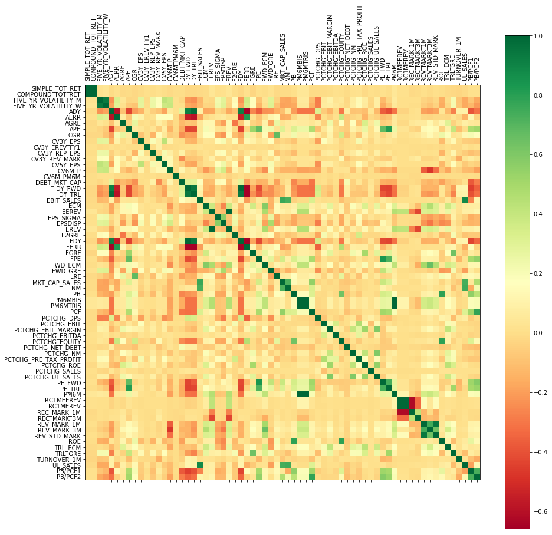

```python
#TOTAL MATRIX CORRELATION

df_tot = df.drop(['REF_DATE','SEDOLCHK','ICB_INDUSTRY_NUM', 'ICB_SECTOR_NUM'], axis = 1)
rho_tot = df_tot.corr()

f = plt.figure(figsize=(15,15))
plt.matshow(rho_tot, fignum=f.number)
plt.set_cmap('RdYlGn')
plt.xticks(range(df_tot.shape[1]), df_tot.columns, fontsize=10, rotation=90)
plt.yticks(range(df_tot.shape[1]), df_tot.columns, fontsize=10)
cb = plt.colorbar()
cb.ax.tick_params(labelsize=10)
```

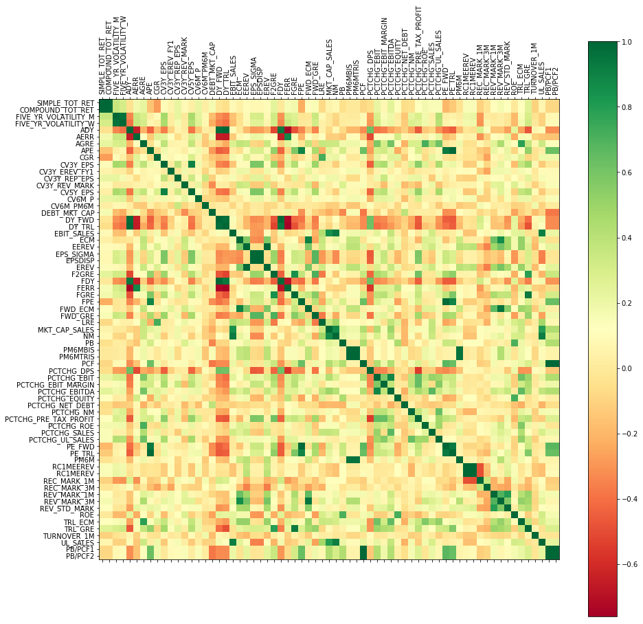

```python
#GROUP MATRIX CORRELATION

df_group = df.groupby(['REF_DATE','ICB_INDUSTRY_NUM'])
#df_group = df.groupby('REF_DATE')
#df_group = df.groupby('ICB_INDUSTRY_NUM')
dates = df.REF_DATE.unique()
industries = df.ICB_INDUSTRY_NUM.unique()
date = dates[6]
industry = industries[2]
df_group = df_group.get_group((date,industry))
#df_group = df_group.get_group(date)
#df_group = df_group.get_group(industry)
df_group = df_group.drop(['REF_DATE','SEDOLCHK','ICB_INDUSTRY_NUM', 'ICB_SECTOR_NUM'], axis = 1)
rho_group = df_group.corr()

f = plt.figure(figsize=(15, 15))
plt.matshow(rho_group, fignum=f.number)
plt.set_cmap('RdYlGn')
plt.xticks(range(df_group.shape[1]), df_group.columns, fontsize=10, rotation=90)
plt.yticks(range(df_group.shape[1]), df_group.columns, fontsize=10)
cb = plt.colorbar()
cb.ax.tick_params(labelsize=10)
```

## 3) Features integration

In this phase there are few trasformations of the features such as the binary encoder for the industries and the label classification (proposed in 3 alternatives)

#### Let's trasform the ICB_INDUSTRY_NUM (10 industry group identifiers) as dummy variables (10 vectors)

```python
lb = preprocessing.LabelBinarizer()
name_list = []
for i in df['ICB_INDUSTRY_NUM'].unique():
    name = 'sector_' + str(i)
    name_list.append(name)
lb.fit(df['ICB_INDUSTRY_NUM'].unique())
sector_df = pd.DataFrame(lb.transform(df['ICB_INDUSTRY_NUM']), columns = name_list)
df = df.join(sector_df, how='outer')
df.head()
```

|  | REF_DATE | SEDOLCHK | SIMPLE_TOT_RET | COMPOUND_TOT_RET | FIVE_YR_VOLATILITY_M | FIVE_YR_VOLATILITY_W | ADY | AERR | AGRE | APE | ... | sector_1 | sector_8000 | sector_5000 | sector_1000 | sector_2000 | sector_9000 | sector_3000 | sector_7000 | sector_4000 | sector_6000 |
| --- | --- | --- | --- | --- | --- | --- | --- | --- | --- | --- | --- | --- | --- | --- | --- | --- | --- | --- | --- | --- | --- |
| 0 | 20050429 | 0028262 | 0.014546 | 0.015183 | 0.374144 | 0.410857 | 0.034056 | 0.583228 | 0.038748 | 12.237950 | ... | 1 | 0 | 0 | 0 | 0 | 0 | 0 | 0 | 0 | 0 |
| 1 | 20050429 | 0038614 | 0.043240 | 0.043240 | 0.243429 | 0.240235 | 0.056665 | 0.424596 | 0.069312 | 9.780680 | ... | 0 | 0 | 0 | 0 | 0 | 0 | 0 | 0 | 1 | 0 |
| 2 | 20050429 | 0044473 | 0.043979 | 0.043979 | 0.457628 | 0.457729 | 0.033439 | 0.485167 | 0.058342 | 15.396250 | ... | 0 | 0 | 0 | 0 | 0 | 1 | 0 | 0 | 0 | 0 |
| 3 | 20050429 | 0045614 | 0.062633 | 0.064127 | 0.330014 | 0.296963 | 0.038021 | 0.720774 | 1.868184 | 7.344045 | ... | 0 | 1 | 0 | 0 | 0 | 0 | 0 | 0 | 0 | 0 |
| 4 | 20050429 | 0047245 | 0.063380 | 0.063380 | 0.380265 | 0.394760 | 0.049925 | 0.411554 | 0.040607 | 11.786590 | ... | 0 | 0 | 0 | 0 | 0 | 1 | 0 | 0 | 0 | 0 |

5 rows × 81 columns

#### Define YEAR and MONTH variables (for rolling window definition) and frop useless columns

```python
df['YEAR'] = df['REF_DATE'].astype(str).str[0:4].astype(int)
df['MONTH'] = df['REF_DATE'].astype(str).str[4:6].astype(int)
df_final=df.drop(['REF_DATE','SEDOLCHK','SIMPLE_TOT_RET','COMPOUND_TOT_RET','YEAR','MONTH','ICB_INDUSTRY_NUM', 'ICB_SECTOR_NUM'], axis = 1)
```

```python
df.to_pickle('DF_Final.pickle')
df_final.to_pickle('DF_FinalX.pickle')
```

### Alternative 1

#### Let's define out target label (y) as a binary classification problem

```python
df=pd.read_pickle('DF_Final.pickle')
df_final=pd.read_pickle('DF_FinalX.pickle')

df_alt1 = df_final.copy()
df_alt1['class_return'] = df['COMPOUND_TOT_RET']
df_alt1['class_return'] = df_alt1['class_return'].where(df['COMPOUND_TOT_RET'] < 0, 0)
df_alt1['class_return'] = df_alt1['class_return'].where(df['COMPOUND_TOT_RET'] >= 0, 1)
df_alt1['class_return'] = df_alt1['class_return'].astype('int')
```

```python
df_alt1.to_pickle('Alternative_1.pickle')
```

### Alternative 2

#### Let's define out target label (y) as a multiclassification problem

Labels:

- 0 : worst quantile within the sector at each t
- 1 : second quantile within the sector at each t
- 2 : third quantile within the sector at each t
- 3 : fourth quantile within the sector at each t
- 4 : best quantile within the sector at each t

```python
df=pd.read_pickle('DF_Final.pickle')
df_final=pd.read_pickle('DF_FinalX.pickle')

df_alt2 = df_final.copy()
df_quant = df.copy()
quantile_list = [0.2, 0.4, 0.6, 0.8]

for i in quantile_list:
    df_quant['quantile_' + str(i)]=df.groupby(['REF_DATE','ICB_INDUSTRY_NUM'])['COMPOUND_TOT_RET'].transform(lambda x: np.quantile(x, i))


#df_alt2['class_return'] = df['COMPOUND_TOT_RET']
conditions = [
    (df_quant['COMPOUND_TOT_RET'] <= df_quant['quantile_0.2']),
    ((df_quant['COMPOUND_TOT_RET'] > df_quant['quantile_0.2']) & (df_quant['COMPOUND_TOT_RET'] <= df_quant['quantile_0.4'])),
    ((df_quant['COMPOUND_TOT_RET'] > df_quant['quantile_0.4']) & (df_quant['COMPOUND_TOT_RET'] <= df_quant['quantile_0.6'])),
    ((df_quant['COMPOUND_TOT_RET'] > df_quant['quantile_0.6']) & (df_quant['COMPOUND_TOT_RET'] <= df_quant['quantile_0.8'])),
     (df_quant['COMPOUND_TOT_RET'] > df_quant['quantile_0.8'])
     ]

choices = [0,1,2,3,4]

df_alt2['class_return'] = np.select(conditions, choices, default='problem')
df_alt2.head()
```

|  | FIVE_YR_VOLATILITY_M | FIVE_YR_VOLATILITY_W | ADY | AERR | AGRE | APE | CGR | CV3Y_EPS | CV3Y_EREV_FY1 | CV3Y_REP_EPS | ... | sector_8000 | sector_5000 | sector_1000 | sector_2000 | sector_9000 | sector_3000 | sector_7000 | sector_4000 | sector_6000 | class_return |
| --- | --- | --- | --- | --- | --- | --- | --- | --- | --- | --- | --- | --- | --- | --- | --- | --- | --- | --- | --- | --- | --- |
| 0 | 0.374144 | 0.410857 | 0.034056 | 0.583228 | 0.038748 | 12.237950 | 0.013896 | 0.083481 | 1.607419 | 0.553340 | ... | 0 | 0 | 0 | 0 | 0 | 0 | 0 | 0 | 0 | 0 |
| 1 | 0.243429 | 0.240235 | 0.056665 | 0.424596 | 0.069312 | 9.780680 | 0.095448 | 0.109293 | 3.127584 | 0.159140 | ... | 0 | 0 | 0 | 0 | 0 | 0 | 0 | 1 | 0 | 2 |
| 2 | 0.457628 | 0.457729 | 0.033439 | 0.485167 | 0.058342 | 15.396250 | -0.039659 | 0.096995 | 4.946424 | 6.783878 | ... | 0 | 0 | 0 | 0 | 1 | 0 | 0 | 0 | 0 | 2 |
| 3 | 0.330014 | 0.296963 | 0.038021 | 0.720774 | 1.868184 | 7.344045 | 0.287677 | 0.588851 | 1.500366 | 0.688070 | ... | 1 | 0 | 0 | 0 | 0 | 0 | 0 | 0 | 0 | 3 |
| 4 | 0.380265 | 0.394760 | 0.049925 | 0.411554 | 0.040607 | 11.786590 | 0.101532 | 0.061296 | 17.671170 | 0.162248 | ... | 0 | 0 | 0 | 0 | 1 | 0 | 0 | 0 | 0 | 3 |

5 rows × 76 columns

#### Check if it's all ok

```python
sum(df_alt2['class_return'] == 'problem')
```

```
0
```

```python
df_alt2.to_pickle('Alternative_2.pickle')
```

### Alternative 3

#### Let's define out target label (y) as a multiclassification problem and our features (X) as 5 quintiles class

Labels:

- 0 : worst quantile within the sector at each t
- 1 : second quantile within the sector at each t
- 2 : third quantile within the sector at each t
- 3 : fourth quantile within the sector at each t
- 4 : best quantile within the sector at each t

All X(i) in X:

- 0 : worst quantile within the sector at each t
- 1 : second quantile within the sector at each t
- 2 : third quantile within the sector at each t
- 3 : fourth quantile within the sector at each t
- 4 : best quantile within the sector at each t

```python
df=pd.read_pickle('DF_Final.pickle')
df_final=pd.read_pickle('DF_FinalX.pickle')

quantile_list = [0.2, 0.4, 0.6, 0.8]
df_quant = pd.DataFrame()
df_alt3 = pd.DataFrame()

for f in df.columns[2:-12]:
    for i in quantile_list:
        df_quant[f + '_' + str(i)] = df.groupby(['REF_DATE','ICB_INDUSTRY_NUM'])[f].transform(lambda x: np.quantile(x, i))


for f in df.columns[2:-12]:
    conditions = [
        (df[f] <= df_quant[f + '_0.2']),
        ((df[f] > df_quant[f + '_0.2']) & (df[f] <= df_quant[f + '_0.4'])),
        ((df[f] > df_quant[f + '_0.4']) & (df[f] <= df_quant[f + '_0.6'])),
        ((df[f] > df_quant[f + '_0.6']) & (df[f] <= df_quant[f + '_0.8'])),
         (df[f] > df_quant[f + '_0.8'])
         ]

    choices = [0,1,2,3,4]

    df_alt3[f] = np.select(conditions, choices, default='problem')

df_alt3['class_return'] = df_alt3['COMPOUND_TOT_RET']
df_alt3=df_alt3.drop(['SIMPLE_TOT_RET','COMPOUND_TOT_RET'], axis = 1)

for i in df['ICB_INDUSTRY_NUM'].unique():
    name = 'sector_' + str(i)
    df_alt3[name] = df[name]

df_alt3.head()
```

|  | FIVE_YR_VOLATILITY_M | FIVE_YR_VOLATILITY_W | ADY | AERR | AGRE | APE | CGR | CV3Y_EPS | CV3Y_EREV_FY1 | CV3Y_REP_EPS | ... | sector_1 | sector_8000 | sector_5000 | sector_1000 | sector_2000 | sector_9000 | sector_3000 | sector_7000 | sector_4000 | sector_6000 |
| --- | --- | --- | --- | --- | --- | --- | --- | --- | --- | --- | --- | --- | --- | --- | --- | --- | --- | --- | --- | --- | --- |
| 0 | 3 | 4 | 3 | 1 | 0 | 2 | 0 | 0 | 2 | 4 | ... | 1 | 0 | 0 | 0 | 0 | 0 | 0 | 0 | 0 | 0 |
| 1 | 1 | 1 | 4 | 1 | 1 | 0 | 3 | 1 | 2 | 1 | ... | 0 | 0 | 0 | 0 | 0 | 0 | 0 | 0 | 1 | 0 |
| 2 | 4 | 4 | 3 | 1 | 1 | 2 | 0 | 1 | 3 | 4 | ... | 0 | 0 | 0 | 0 | 0 | 1 | 0 | 0 | 0 | 0 |
| 3 | 3 | 2 | 3 | 3 | 4 | 0 | 4 | 4 | 0 | 3 | ... | 0 | 1 | 0 | 0 | 0 | 0 | 0 | 0 | 0 | 0 |
| 4 | 3 | 3 | 4 | 0 | 1 | 0 | 2 | 0 | 4 | 1 | ... | 0 | 0 | 0 | 0 | 0 | 1 | 0 | 0 | 0 | 0 |

5 rows × 78 columns

```python
df_alt3.to_pickle('Alternative_3.pickle')
```

## 4) Modelling and Evaluation

The following function train and test the algos on the dataset based on the rolling window indexing depending on the State variable "year" which decides the lenght of the training period

#### Function to plot the Confusion matrix

```python
#Function for the confusion matrix graph

def plot_confusion_matrix(y_true, y_pred, classes,
                          cm = None,
                          normalize = True,
                          title = None,
                          cmap = plt.cm.Blues):
    """
    This function prints and plots the confusion matrix.
    Normalization can be applied by setting `normalize=True`.
    """
    if not title:
        if normalize:
            title = 'Normalized confusion matrix'
        else:
            title = 'Confusion matrix, without normalization'

    # Compute confusion matrix
    if cm is None:
        cm = confusion_matrix(y_true, y_pred)

    if normalize:
        cm = cm.astype('float') / cm.sum(axis=1)[:, np.newaxis]

    fig, ax = plt.subplots()
    im = ax.imshow(cm, interpolation='nearest', cmap=cmap)
    ax.figure.colorbar(im, ax=ax)
    # We want to show all ticks...
    ax.set(xticks=np.arange(cm.shape[1]),
           yticks=np.arange(cm.shape[0]),
           # ... and label them with the respective list entries
           xticklabels=classes, yticklabels=classes,
           title=title,
           ylabel='True label',
           xlabel='Predicted label')

    # Rotate the tick labels and set their alignment.
    plt.setp(ax.get_xticklabels(), rotation=45, ha="right",
             rotation_mode="anchor")

    # Loop over data dimensions and create text annotations.
    fmt = '.2f' #if normalize else 'd'
    thresh = cm.max() / 2.
    for i in range(cm.shape[0]):
        for j in range(cm.shape[1]):
            ax.text(j, i, format(cm[i, j], fmt),
                    ha="center", va="center",
                    color="white" if cm[i, j] > thresh else "black")
    fig.tight_layout()
    return ax
```

```python
def time_model(model, years, original_df, alternative_df, capital, leverage, threshold):

    time_breakdown = []
    for i in original_df['YEAR'].unique():
        for x in sorted(original_df['MONTH'].unique()):
            step = alternative_df[original_df['YEAR'] == i][original_df['MONTH'] == x]
            if len(step) > 0:
                time_breakdown.append(step.index.values)

    test_list = []
    for i in range(0,len(time_breakdown)):
        test = time_breakdown[i][0], time_breakdown[i][-1]
        test_list.append(test)

    train_list = []
    learning_period = years * 12 - 1

    for i in range(0, len(test_list)):
        if i + (years * 12 - 1) < len(test_list):
            train = [test_list[i][0],test_list[i + learning_period][1]]
            train_list.append(train)

    date_list = []
    quarter_rate_list = []

    accurancy_train_list = []
    precision_train_list = []

    accurancy_test_list = []
    precision_test_list = []

    y_train_list = []
    y_train_predict_list = []

    y_test_list = []
    y_test_predict_list = []

    positive_predictions_list = []

    strategy1 = []
    strategy2 = []
    benchmark = []
    capital_1 = capital
    capital_2 = capital
    capital_b = capital

    compounding_months = 0

    for i in range(0,len(train_list)):

        #Creating the train and test sets for all the steps (in function of the i-step)

        if i + learning_period + 1 < len(test_list):

            #Building training/testing set

            X_plain_train = np.c_[alternative_df[train_list[i][0]:(train_list[i][1] + 1)].drop(['class_return'], axis = 1)]
            y_plain_train = np.c_[alternative_df[train_list[i][0]:(train_list[i][1] + 1)]['class_return']]

            X_plain_test = np.c_[alternative_df[test_list[i + learning_period + 1][0]:(test_list[i + learning_period + 1][1] + 1)].drop(['class_return'], axis = 1)]
            y_plain_test = np.c_[alternative_df[test_list[i + learning_period + 1][0]:(test_list[i + learning_period + 1][1] + 1)]['class_return']]

            compounding_months = compounding_months + 1

            #Scaling training/testing dataset

            min_max_scaler = preprocessing.MinMaxScaler()

            X_scaled_train = min_max_scaler.fit_transform(X_plain_train)
            y_scaled_train = min_max_scaler.fit_transform(y_plain_train)
            X_scaled_test = min_max_scaler.fit_transform(X_plain_test)
            y_scaled_test = min_max_scaler.fit_transform(y_plain_test)

            X_train = X_scaled_train
            y_train = y_plain_train
            X_test = X_scaled_test
            y_test = y_plain_test

            #--------------Fit Model-------------

            clf = model
            clf.fit(X_train, y_train)

            y_train_predict = clf.predict(X_train)
            y_train_list.append(y_train)
            y_train_predict_list.append(y_train_predict)

            y_test_predict = clf.predict(X_test)
            y_test_list.append(y_test)
            y_test_predict_list.append(y_test_predict)  # List of all the predictions

            #Precision-Accuracy

            accurancy_train_list.append(accuracy_score(y_train,y_train_predict, normalize=True))
            precision_train_list.append(precision_score(y_train,y_train_predict, average='weighted'))

            accurancy_test_list.append(accuracy_score(y_test,y_test_predict, normalize=True))
            precision_test_list.append(precision_score(y_test,y_test_predict, average='weighted'))

            #--------Implementing strategy----------

            y_origin_test = np.c_[original_df[test_list[i + learning_period + 1][0]:(test_list[i + learning_period + 1][1] + 1)]['COMPOUND_TOT_RET']]
            y_test_predict_num = y_test_predict.astype(int)
            total_return = y_test_predict_num.sum()
            total_observ = len(y_test_predict)

            #Startegy 1 (return-weighted)
            if total_return == 0:
                weights = np.ones(y_test_predict_num.shape)/total_observ #Equally-weighted
            else:
                weights = y_test_predict_num/total_return #Return-weighted
            weights = (weights.reshape((1 + y_origin_test).shape))
            capital_1 = capital_1 * np.sum(weights * (1 + y_origin_test))
            strategy1.append(capital_1)

            #Startegy 2 (long-short-weighted)
            rmax = y_test_predict_num.max()
            weightsL = np.zeros(y_test_predict.shape)
            weightsL[y_test_predict_num == rmax] = 1
            if weightsL.sum() > 0:
                weightsL = weightsL/weightsL.sum()
            weightsL = (weightsL.reshape((1 + y_origin_test).shape)) #Long-weights

            rmin = y_test_predict_num.min()
            weightsS = np.zeros(y_test_predict.shape)
            weightsS[y_test_predict_num == rmin] = 1
            if weightsS.sum() > 0:
                weightsS = weightsS/weightsS.sum()
            weightsS = (weightsS.reshape((1 + y_origin_test).shape)) #Short-weights

            capital_2 = capital_2 * ((1+leverage) * np.sum(weightsL * (1 + y_origin_test)) - leverage * np.sum(weightsS * (1 + y_origin_test)))
            strategy2.append(capital_2)

            #Benchmark
            weights = 1/total_observ
            capital_b = capital_b * np.sum(weights *  (1 + y_origin_test))
            benchmark.append(capital_b)


    y_train_total = np.concatenate((y_train_list))
    y_train_predict_total = np.concatenate((y_train_predict_list))

    y_test_total = np.concatenate((y_test_list))
    y_test_predict_total = np.concatenate((y_test_predict_list))


    y1 = accurancy_train_list
    y2 = precision_train_list
    y3 = np.ones(len(precision_train_list)) * threshold

    y4 = accurancy_test_list
    y5 = precision_test_list
    y6 = np.ones(len(precision_test_list)) * threshold


    #y7 = quarter_rate_list
    #y8 = positive_predictions_list

    year_train = original_df['YEAR'].unique()
    year_test = original_df['YEAR'].unique()
    for i in range(0,years):
        year_test = np.delete(year_test,[0])

    x1 = np.arange(0,len(y1))
    x2 = np.arange(0,len(y4))

    ax = []
    plt.figure(0, figsize=(20, 50))

    ax.append(plt.subplot2grid((5,1), (0,0)))
    ax.append(plt.subplot2grid((5,1), (1,0)))
    #ax.append(plt.subplot2grid((5,1), (2,0)))


    ax[0].plot(x1, y1, label = 'accurancy',color = 'b')
    ax[0].plot(x1, y2, label = 'precision',color = 'g')
    ax[0].plot(x1, y3, label = 'threshold',color = 'r')


    ax[0].set_title('TRAIN METRICS', fontsize = 25)
    ax[0].legend(loc='best',fontsize = 15)
    ax[0].set_ylabel('%',fontsize = 15)
    ax[0].set_xticks(np.arange(0,len(x1),len(x1)/len(year_train)))
    ax[0].set_xticklabels(year_train, fontsize=15)
    ax[0].set_xlabel('DATE',fontsize = 15)
    ax[0].set_ylim([0, 1])

    ax[1].plot(x2, y4, label = 'accurancy',color = 'b')
    ax[1].plot(x2, y5, label = 'precision',color = 'g')
    ax[1].plot(x2, y6, label = 'threshold',color = 'r')


    ax[1].set_title('TEST METRICS', fontsize = 25)
    ax[1].legend(loc='best',fontsize = 15)
    ax[1].set_ylabel('%',fontsize = 15)
    ax[1].set_xticks(np.arange(0,len(x2),len(x2)/len(year_test)))
    ax[1].set_xticklabels(year_test, fontsize=15)
    ax[1].set_ylim([0, 1])

    print('TRAINING SET \n')
    print('mean accurancy: ' + '{:.2%}'.format(np.mean(accurancy_train_list)))
    print('mean precision: '+ '{:.2%}'.format(np.mean(precision_train_list)))
    print('\n')

    print('TESTING SET \n')
    print('mean accurancy: ' + '{:.2%}'.format(np.mean(accurancy_test_list)))
    print('mean precision: '+ '{:.2%}'.format(np.mean(precision_test_list)))
    print('\n')

    #fig3 = plt.figure(figsize=(9,3))
    #ax1 = fig3.add_subplot(121)
    plot_confusion_matrix(y_train_total, y_train_predict_total, title = 'Confusion Matrix - Train set', classes = [0,1,2,3,4])
    #ax2 = fig3.add_subplot(122)
    plot_confusion_matrix(y_test_total, y_test_predict_total, title = 'Confusion Matrix - Test set',classes = [0,1,2,3,4])

    plt.figure(3, figsize=(15, 10))
    plt.plot(strategy1, label = 'strategy1', color = 'blue', marker='')
    plt.plot(strategy2, label = 'strategy2', color = 'green', marker='')
    plt.plot(benchmark, label = 'benchmark', color = 'red', marker='')
    plt.title('Capital gain', fontsize = 15)
    plt.legend(loc='best',fontsize = 15)
    plt.ylabel('Capital $',fontsize = 10)
    plt.xticks(np.arange(0,len(strategy1),len(strategy1)/len(year_test)), year_test)
    plt.xlabel('Time',fontsize = 10)

    strategy1_tot_ret = (strategy1[-1] - capital) / capital
    strategy2_tot_ret = (strategy2[-1] - capital) / capital
    benchmark_tot_ret = (benchmark[-1] - capital) / capital

    strategy1_yrl_ret = pow((strategy1[-1] / capital), 12 / compounding_months) - 1
    strategy2_yrl_ret = pow((strategy2[-1] / capital), 12 / compounding_months) - 1
    benchmark_yrl_ret = pow((benchmark[-1] / capital), 12 / compounding_months) - 1

    print('STRATEGY RETURN \n')
    print('Strategy 1 total return: ' + '{:.2%}'.format(strategy1_tot_ret))
    print('Strategy 1 yearly return: ' + '{:.2%}'.format(strategy1_yrl_ret))
    print('\n')
    print('Strategy 2 total return: ' + '{:.2%}'.format(strategy2_tot_ret))
    print('Strategy 2 yearly return: ' + '{:.2%}'.format(strategy2_yrl_ret))
    print('\n')
    print('Benchmark total return: ' + '{:.2%}'.format(benchmark_tot_ret))
    print('Benchmark yearly return: ' + '{:.2%}'.format(benchmark_yrl_ret))

    #return capital, capital_benchmark, year_test
```

### Testing Alternative 1

```python
df=pd.read_pickle('DF_Final.pickle')
df_alt1=pd.read_pickle('Alternative_1.pickle')

histo_depth = 8 # in years
capital = 100.00
leverage = 0.20
threshold = 0.50
```

##### a) Logistic Regression

```
TRAINING SET

mean accurancy: 56.41%
mean precision: 55.59%


TESTING SET

mean accurancy: 51.81%
mean precision: 57.32%


STRATEGY RETURN

Strategy 1 total return: 65.34%
Strategy 1 yearly return: 8.38%


Strategy 2 total return: 66.75%
Strategy 2 yearly return: 8.53%


Benchmark total return: 75.39%
Benchmark yearly return: 9.41%
```

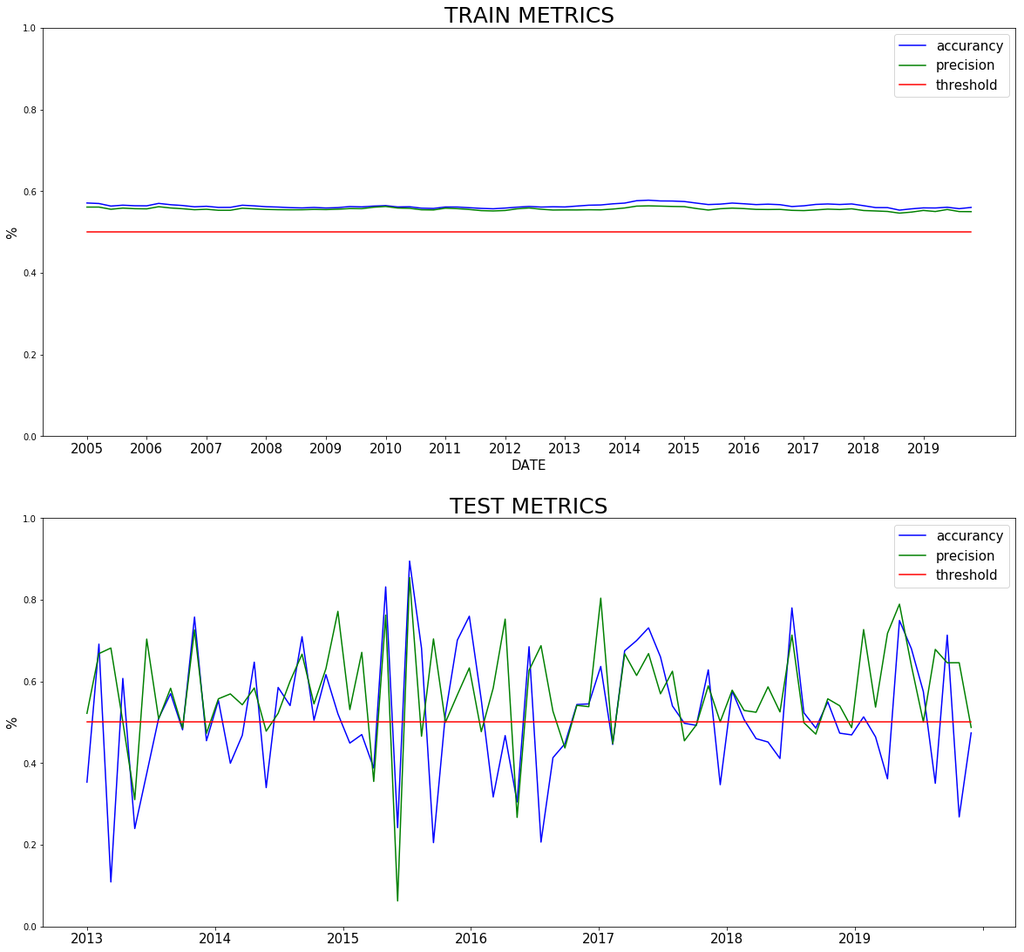

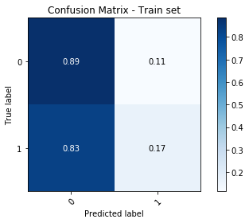

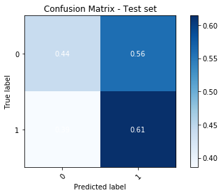

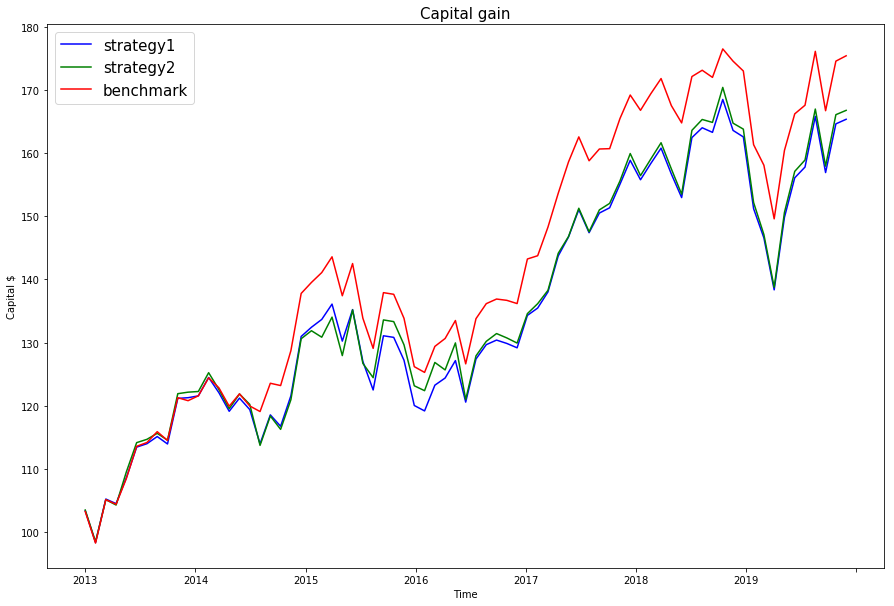

```python
time_model(LogisticRegression(), histo_depth, df, df_alt1, capital, leverage, threshold)
```

##### b) Ridge Classifier

```
TRAINING SET

mean accurancy: 56.43%
mean precision: 55.61%


TESTING SET

mean accurancy: 51.99%
mean precision: 57.78%


STRATEGY RETURN

Strategy 1 total return: 65.87%
Strategy 1 yearly return: 8.43%


Strategy 2 total return: 65.22%
Strategy 2 yearly return: 8.36%


Benchmark total return: 75.39%
Benchmark yearly return: 9.41%
```

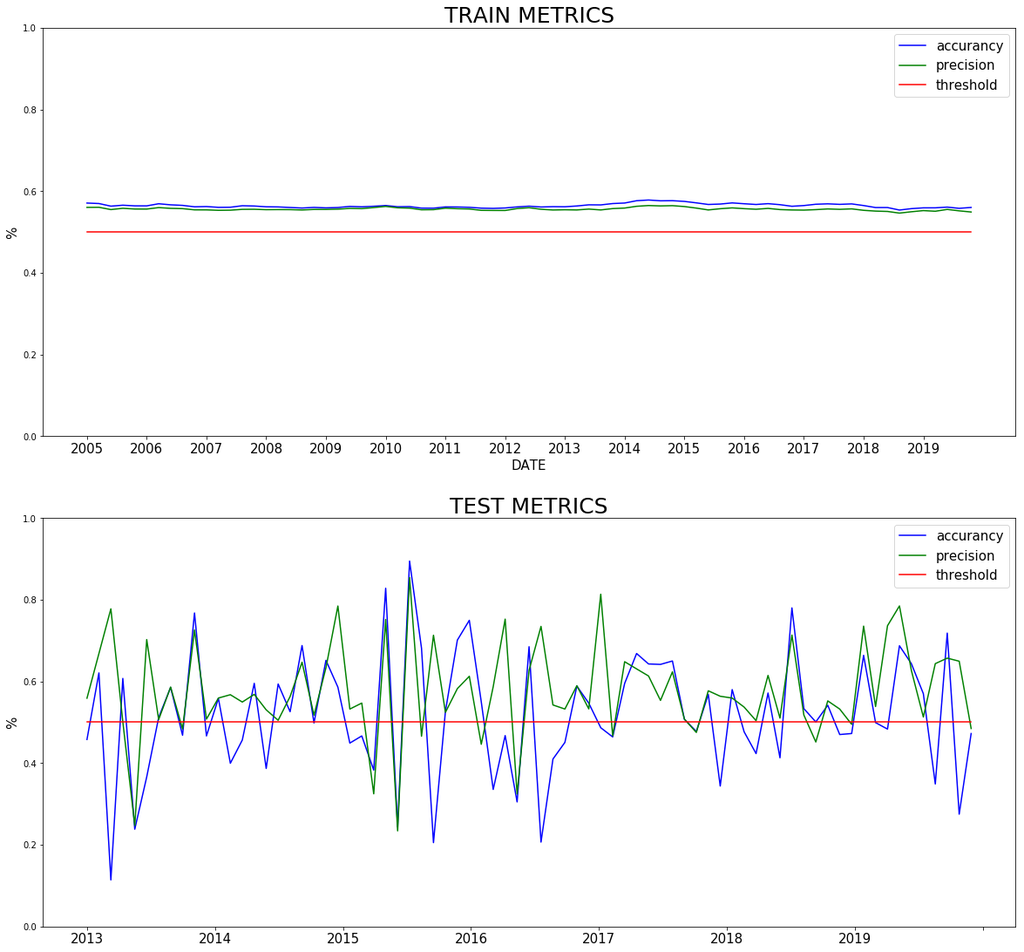

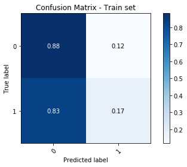

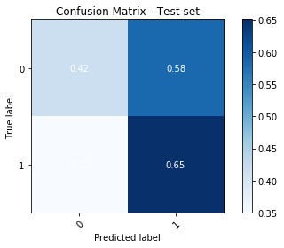

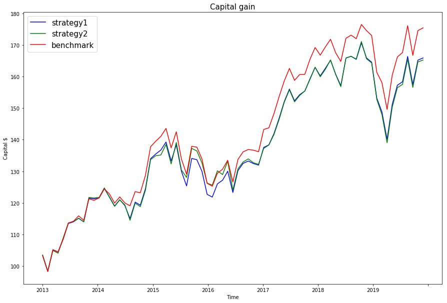

```python
time_model(RidgeClassifier(), histo_depth, df, df_alt1, capital, leverage, threshold)
```

##### c) Random Forest

```
TRAINING SET

mean accurancy: 59.10%
mean precision: 63.67%


TESTING SET

mean accurancy: 53.77%
mean precision: 58.51%


STRATEGY RETURN

Strategy 1 total return: 30.08%
Strategy 1 yearly return: 4.30%


Strategy 2 total return: 21.29%
Strategy 2 yearly return: 3.14%


Benchmark total return: 75.39%
Benchmark yearly return: 9.41%
```

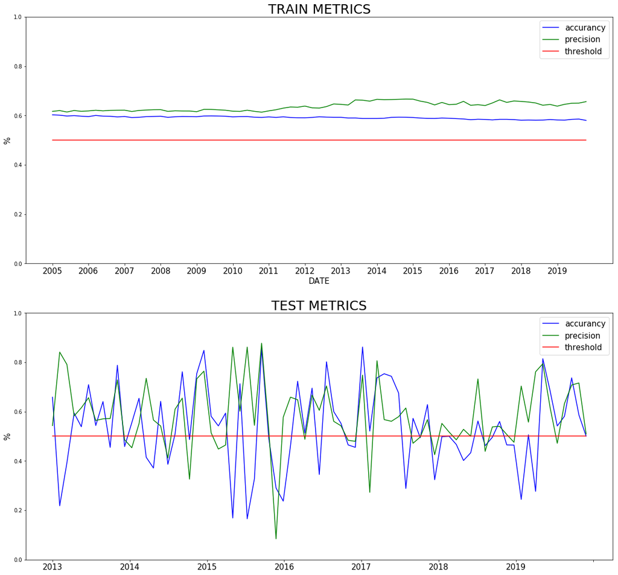

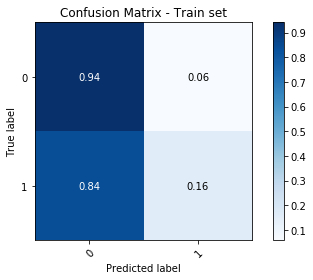

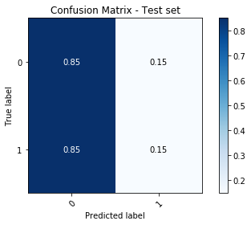

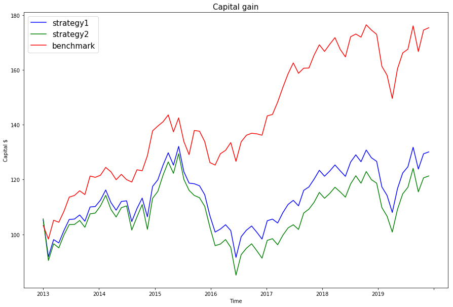

```python
time_model(RandomForestClassifier(n_estimators=50, max_leaf_nodes=50, n_jobs=-1, random_state=42),
           histo_depth, df, df_alt1, capital, leverage, threshold)
```

### Alternative 2

```python
df=pd.read_pickle('DF_Final.pickle')
df_alt2=pd.read_pickle('Alternative_2.pickle')

histo_depth = 8 # in years
capital = 100.00
leverage = 0.20
threshold = 0.20
```

##### a) Logistic Regression

```
TRAINING SET

mean accurancy: 24.98%
mean precision: 24.68%


TESTING SET

mean accurancy: 22.79%
mean precision: 21.80%


STRATEGY RETURN

Strategy 1 total return: 89.85%
Strategy 1 yearly return: 10.80%


Strategy 2 total return: 80.64%
Strategy 2 yearly return: 9.92%


Benchmark total return: 75.39%
Benchmark yearly return: 9.41%
```

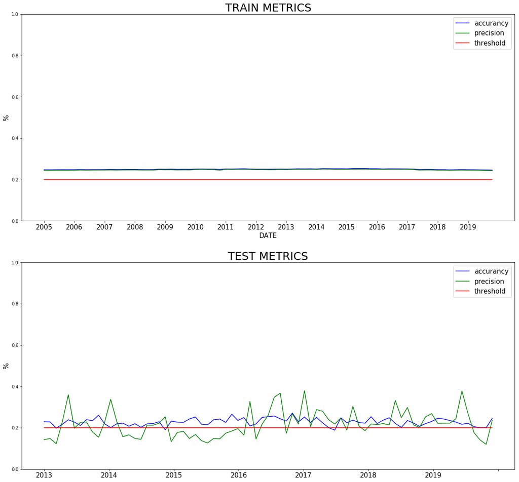

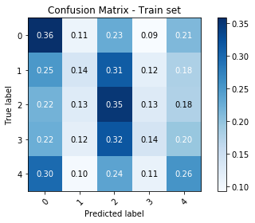

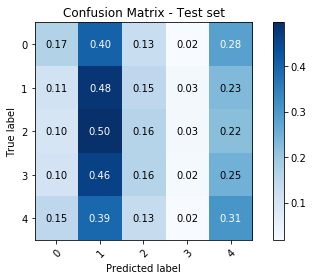

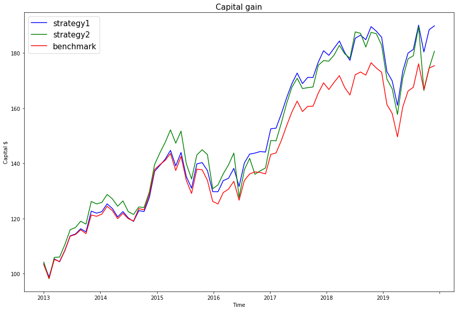

```python
time_model(LogisticRegression(), histo_depth, df, df_alt2, capital, leverage, threshold)
```

##### b) Ridge Classifier

```
TRAINING SET

mean accurancy: 25.04%
mean precision: 24.73%


TESTING SET

mean accurancy: 22.33%
mean precision: 18.69%


STRATEGY RETURN

Strategy 1 total return: 80.06%
Strategy 1 yearly return: 9.87%


Strategy 2 total return: 75.49%
Strategy 2 yearly return: 9.42%


Benchmark total return: 75.39%
Benchmark yearly return: 9.41%
```

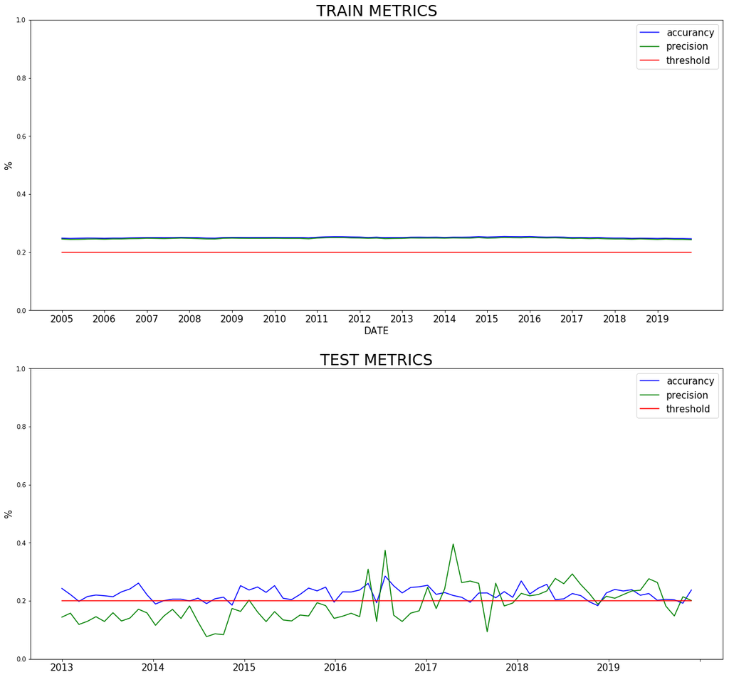

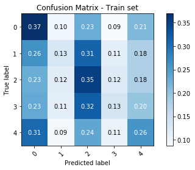

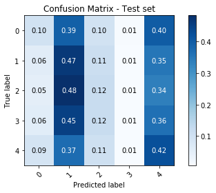

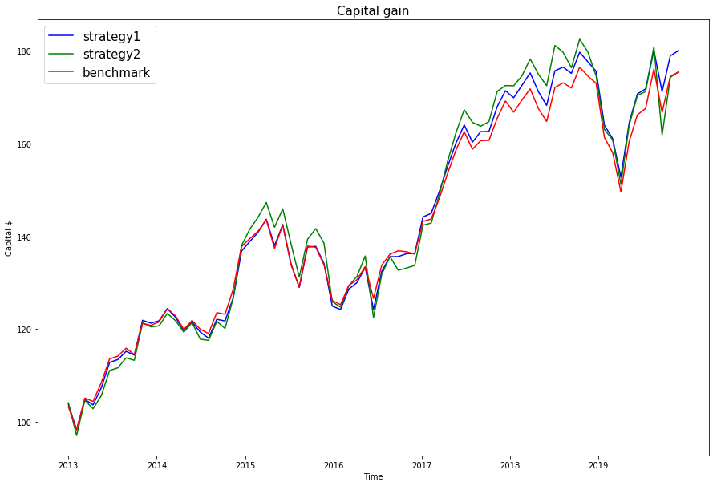

```python
time_model(RidgeClassifier(), histo_depth, df, df_alt2, capital, leverage, threshold)
```

##### c) Random Forest

```
TRAINING SET

mean accurancy: 29.09%
mean precision: 30.11%


TESTING SET

mean accurancy: 21.93%
mean precision: 22.51%


STRATEGY RETURN

Strategy 1 total return: 65.92%
Strategy 1 yearly return: 8.44%


Strategy 2 total return: 59.24%
Strategy 2 yearly return: 7.73%


Benchmark total return: 75.39%
Benchmark yearly return: 9.41%
```

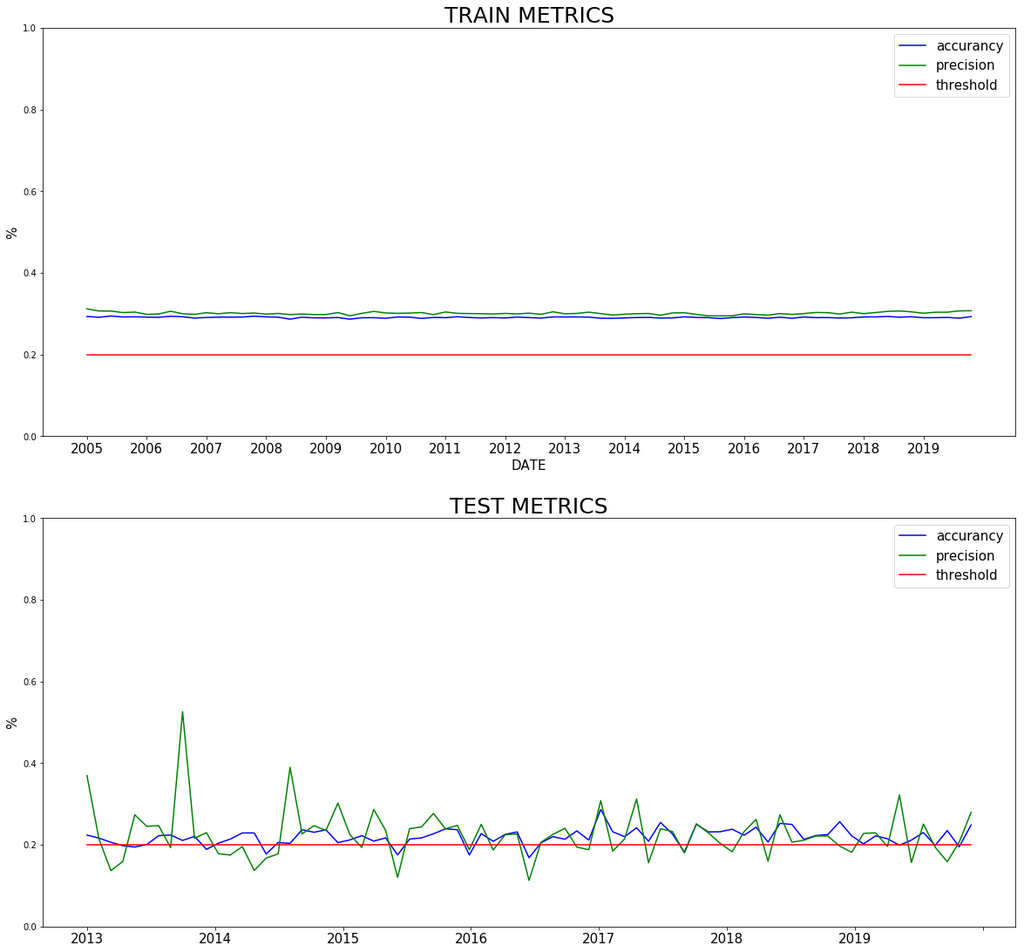

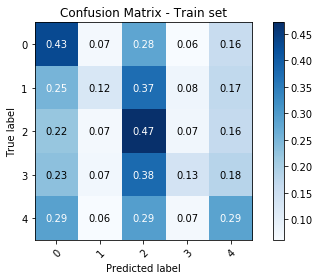

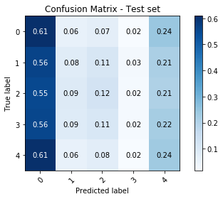

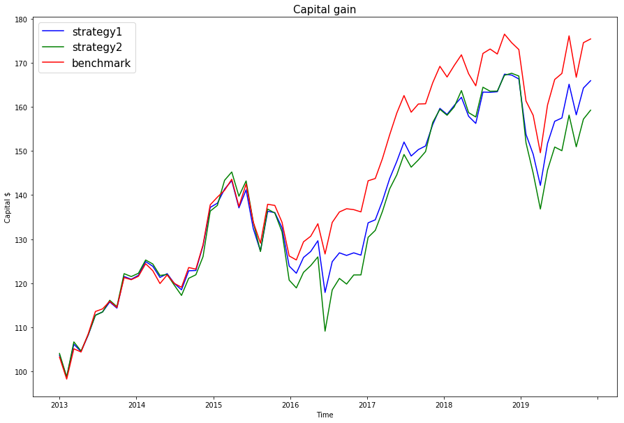

```python
time_model(RandomForestClassifier(n_estimators=50, max_leaf_nodes=50, n_jobs=-1, random_state=42),
           histo_depth, df, df_alt2, capital, leverage, threshold)
```

### Alternative 3

```python
df=pd.read_pickle('DF_Final.pickle')
df_alt3=pd.read_pickle('Alternative_3.pickle')

histo_depth = 8 # in years
capital = 100.00
leverage = 0.20
threshold = 0.20
```

##### a) Logistic Regression

```
TRAINING SET

mean accurancy: 25.54%
mean precision: 25.07%


TESTING SET

mean accurancy: 24.08%
mean precision: 23.53%


STRATEGY RETURN

Strategy 1 total return: 88.99%
Strategy 1 yearly return: 10.72%


Strategy 2 total return: 103.97%
Strategy 2 yearly return: 12.08%


Benchmark total return: 75.39%
Benchmark yearly return: 9.41%
```

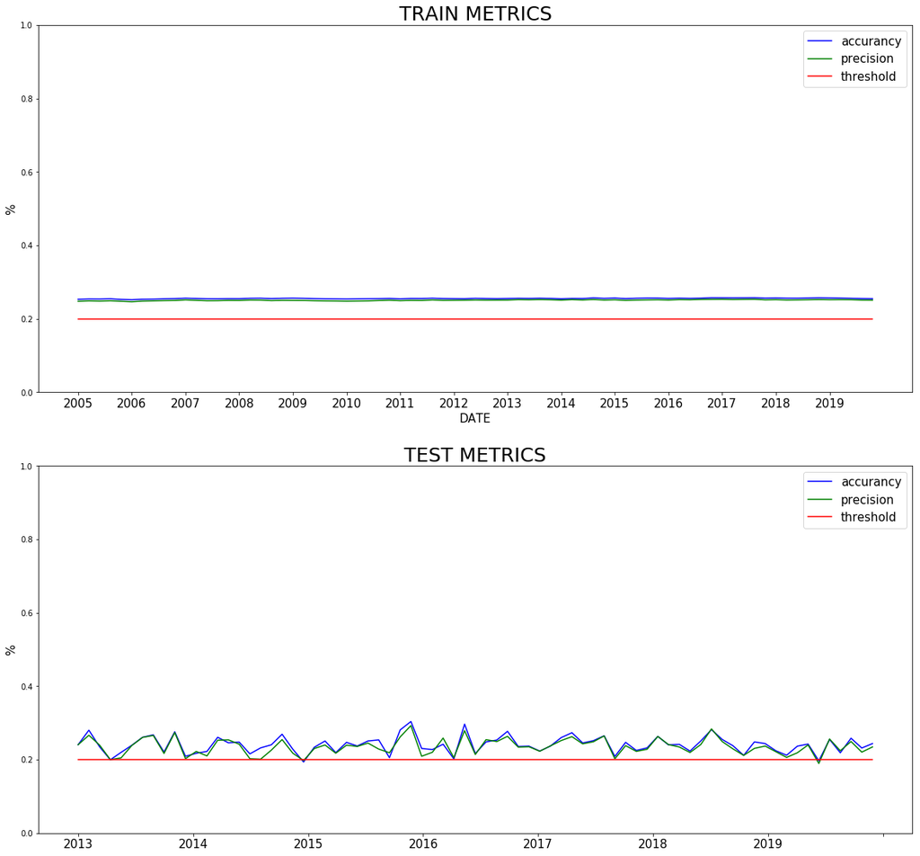

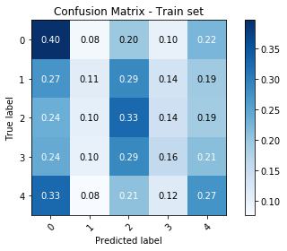

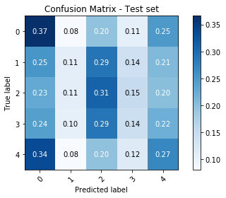

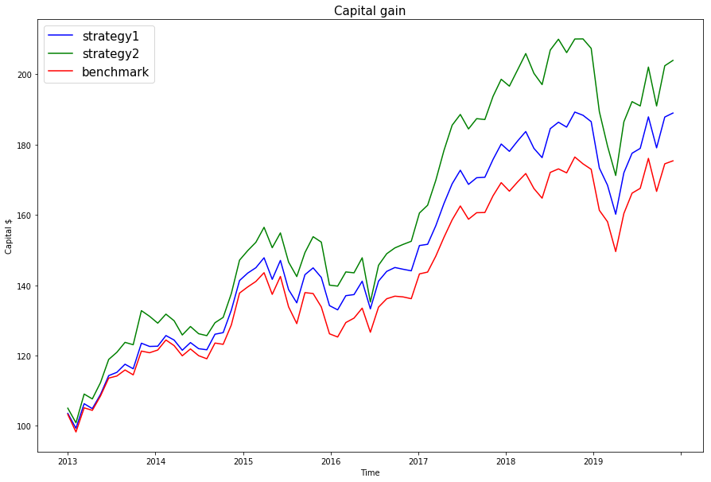

```python
time_model(LogisticRegression(), histo_depth, df, df_alt3, capital, leverage, threshold)
```